# Influenza Data Analysis

Mikah Nelson

2023-09-08

### Notes About the Original Graph

The original graphical display is a numerical column full of arrays, buried within pages of deaths from influenza, representing Philadelphia deaths resulting from a combination of influenza or pneumonia. Philadelphia was an epicenter for the influenza outbreak of 1918, but the data itself was consolidated in 1919. Small text at the top says “[This table excludes the deaths of soldiers, sailors, and marines.]”, and the title of the graph itself is deaths in Philadelphia during 1918 by “country of birth of mother”.

### Statement of Method

I wanted my graphical display to transcend static data without context. This is apparent both in the navigation to this page, built into a personal website, in the display, which is a pdf document written in open source code, and the visual product is modern representation of under represented data. The webpage is hand coded in HTML and CSS, and the display itself emphasizes how the original display omitted the categorization of non-white people through accompanying text and through a logical narrative.

#### Details

The details of my reinterpretation of the data in its initial form try and modify the numerical outputs of deaths in three key ways. First, the columns and arrays of death count are no longer numerical, but represented in scale of circles. The larger the circle, the higher the reported death count, and the smaller it is the smaller the reported death count. I believe that seeing the scale of deaths, overlapping at times due to the difference in size, highlights the scope of those who died more effectively than a column at a quick glance. Next, I made sure to color the non white participants a striking color to emphasize the little representation they received in comparison to white individuals’ data. Even those from “country not stated” were white individuals, and I felt like this exclusion of not specifying what nonwhite mothers’ countries were from was important. Lastly, I embedded the graph with detailed explanations regarding my R code, which helps with the transparency and detailing of why I chose to represent my elements and helps with reproducing the graph, to tweak it to personal interpretation.

#### Theoretical Basis

To tie this project to a wider and more theoretical context, representations of public health are complex abstractions of how securitization and a transformation of public data is taken as a given. To combat the standing power that public health represents, the idea of given data, collected by epidemiological researchers, can be scrutinized by redefining it as capta (Drucker 2011). To that end, I wanted to create a representation of interactive data, reimagining what the numerical collection of data from 1918 looked like.

Such exclusions may be dictated by biopolitics; in the public health context, we see that that a biopolitical government generally “aims to maximize the biological quality and productive capacity of a population by dividing people into subcategories that are either valuable to the stability and profitability of the nation- state or not” (Schuller, 2020). When distinction and care is given to the population that is “valuable”, as indicated by the numerous countries of birth of mother that white citizens were given, as opposed to the aggregate category given to “colored” people in the original graph, it is easy to see the importance give to the more ‘profitable’ group. Additionally, this desire to track data through initial countries of the mothers of the individuals, not the individuals themselves, may fall into the “desire to map and thus regulate the flow of bodies in the public sphere that has drive health surveillance” (Ostherr, 2005).

Although I am perpetuating this dissemination of information regarding the regulation of bodies according to data, I hope this representation sheds light on the current practices surrounding what data means to the public, and how bio politics intersects with representing individual bodies in a binary.

### Citations

Drucker, J. (2011). Humanities approaches to graphical display. Digital Humanities Quarterly, 5(1). Ostherr, K. (2005). Cinematic prophylaxis: Globalization and contagion in the discourse of world health. Duke University Press. Schuller, K. (2020). 6 Biopolitics. In Keywords for American Cultural Studies, Third Edition (pp. 22-26). New York University Press.

### Packages

```r
#import data set from local computer

influenza <-
  read.csv('/Users/mikah/Desktop/Rstudiodata/eng 148en/mortality influenza by mother birth country - raw.csv')

library(pacman)

p_load(dplyr, tidyverse, ggplot2, gridExtra, hrbrthemes, ggrepel, stats)
```

### Modify Data Frame

```r
#Modify data to create a graph with package ggplot2

influenzaLong <- influenza %>%
  pivot_longer(c(2:29), names_to = "PID", values_to = "deaths")
print(influenzaLong)
```

```
## # A tibble: 392 × 3
##    age.range PID                          deaths
##    <chr>     <chr>                         <int>
##  1 20        us.male                          33
##  2 20        us.female                        56
##  3 20        austria.male                      1
##  4 20        austria.female                    2
##  5 20        hungary.male                     NA
##  6 20        hungary.female                    4
##  7 20        canada.male                      NA
##  8 20        canada.female                    NA
##  9 20        denmark.norway.sweden.male        1
## 10 20        denmark.norway.sweden.female     NA
## # ℹ 382 more rows
```

```r
#omit the cases where NA is true
influenzaComplete<- influenzaLong[complete.cases(influenzaLong),]

#rename column to fit R expectations
influenzaComplete <- setNames(influenzaLong, c("age","PID", "deaths"))
```

### Analysis

```r
#Analysis#

#Create plot

influenzaPlot <- ggplot(influenzaComplete,
                        aes(x = age, y = PID, size = deaths)) +
  geom_point(shape = 21,

             #insert code for specifying that nonwhite individuals will be a different color on your graph
             col = ifelse (
               influenzaComplete$PID == c('nonwhite.male', 'nonwhite.female'),
               "red",
               "black"
             )) +

  #specify how large the circles should be
  scale_size(range = c(.1, 11)) +

  labs(
    x = "Age in Years",
    y = "White and Nonwhite People by Country of Birth of Mother",
    title = "Where are Nonwhite Mothers From?",
    subtitle = "Influenza and Pneumonia Deaths By Country of Birth of Mother in Philadelphia,
        CDC 1919"
  )
```

The original graph can be found here: https://www.cdc.gov/nchs/data/vsushistorical/morttable_1918.pdf . To note, this graph, like the original table, must omit “the deaths of soldiers, sailors, and marines”.

The original statisticians of the original table are Dr. William H. Davis, “chief statistician for vital statistics”, Mr. John B. Mitchell, “expert chief of division”, and Sam L. Rogers “Director of the Census” (Rogers, 1920).

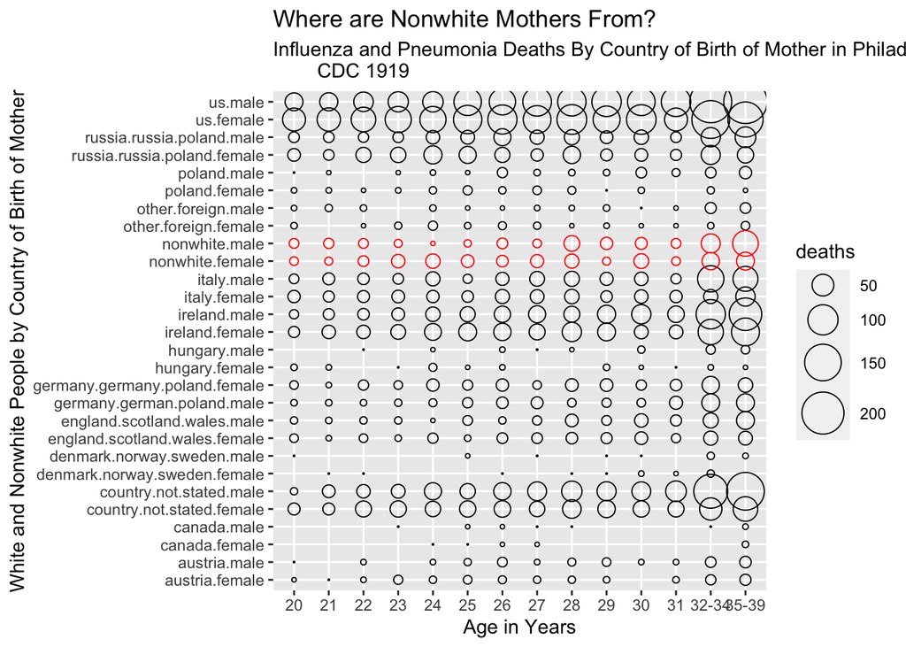

```r
#Generate Plot#
influenzaPlot
```